# Insurance Fraud

Frank Lauder

2025-03-30

# Introduction

Insurance fraud poses a concern across various sectors, including healthcare, homeownership, and automobile coverage. Its impact extends beyond the financial burden on insurers, affecting even non-fraudulent policyholders.

This analysis zeroes in on fraud within the auto insurance industry in India. The dataset utilized for this project was sourced from Kaggle (https://www.kaggle.com/).

Our objective is to leverage classification models to predict fraudulent auto insurance claims. Various classification models will be evaluated based on their efficacy in accurately predicting instances of actual fraud.

Individuals may not have an interest in every section of this analysis. Specific sections of interest can be directly accessed through the table of contents on the left. For instance, clicking on “Models” will swiftly take one to the classification models section.

The end-to-end process along with the accompanying code for this project can be viewed by following the below link.

[End-to-End Project With Code](https://franklauder.github.io/AutoInsuranceFraud/InsuranceFraudWcode.html)

# Exploratory Data Analysis

## Visualization

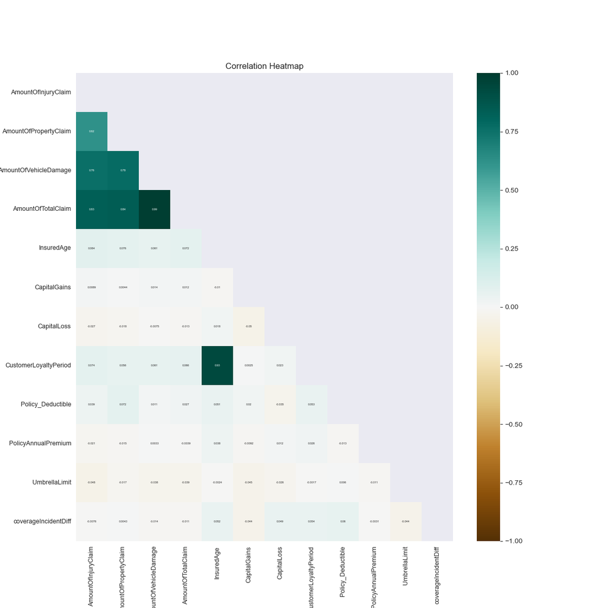

There is very high to high correlation between Amount of Injury Claim, Amount of Property Claim, Amount of Vehicle Damage, and Amount of Total Claim. This is unsurprising as Amount of Total Claim is the sum of the other three. Amount of Total Claim is the only feature of the four that will be used for our machine learning models.

Other features exhibiting very high correlation are Loyalty period and Age. This makes sense as older customers have the chance to accrue loyalty time based on having lived longer than younger customers. Still, we will retain both features for our models.

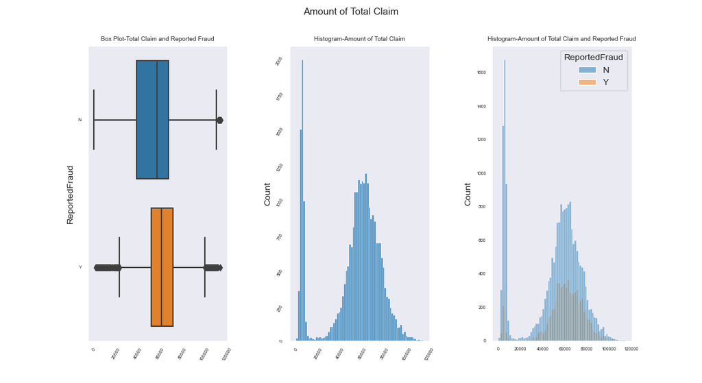

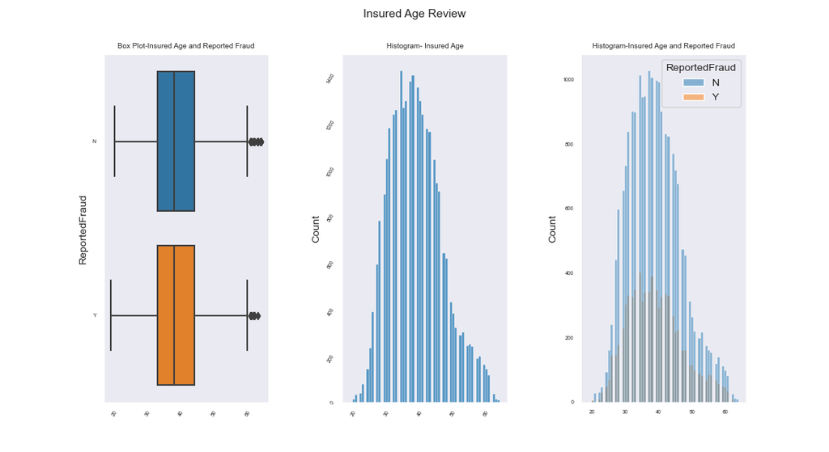

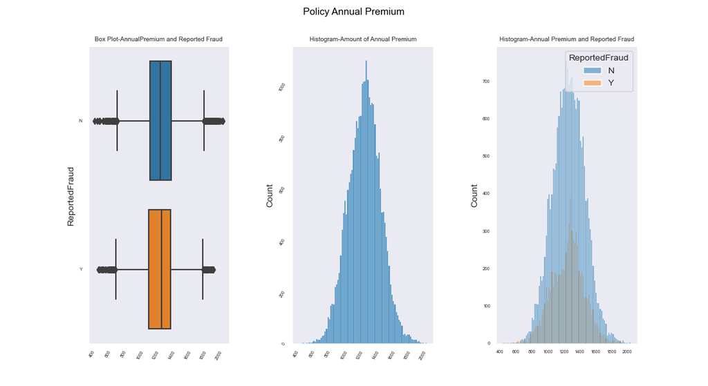

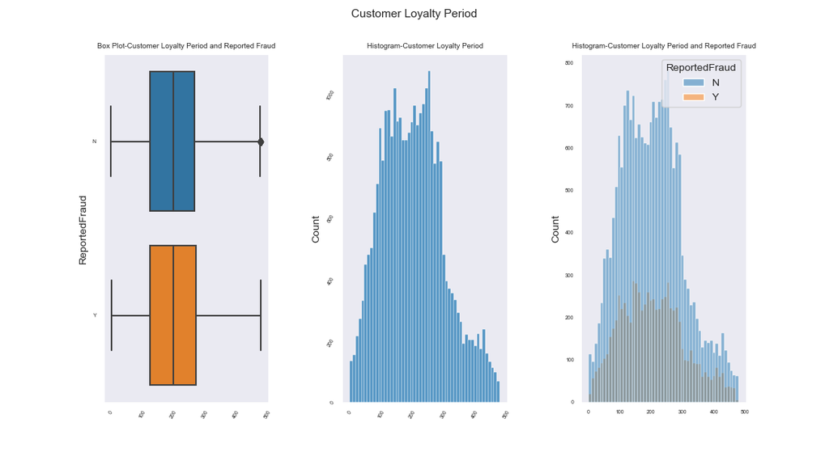

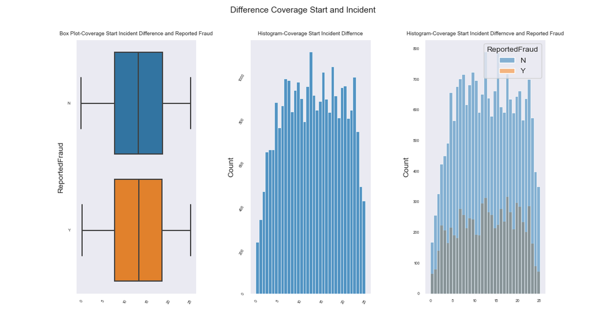

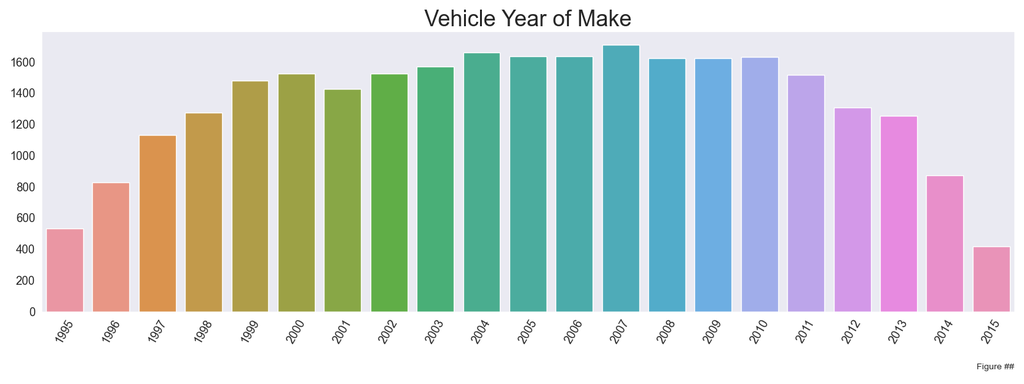

Auto insurance premiums are generally based on personal details like choice of coverage, type of vehicle driven, and age of car. The newer the car, typically the more expensive the insurance. This is based on the vehicle’s replacement cost. The year the car was manufactured plays just as big a part in the premium as the make and model itself. The above plot displays all years of vehicle make in our data set. We find that there are just over 6000 auto’s that have an age of 15 years or greater compared to the last year of 2015.

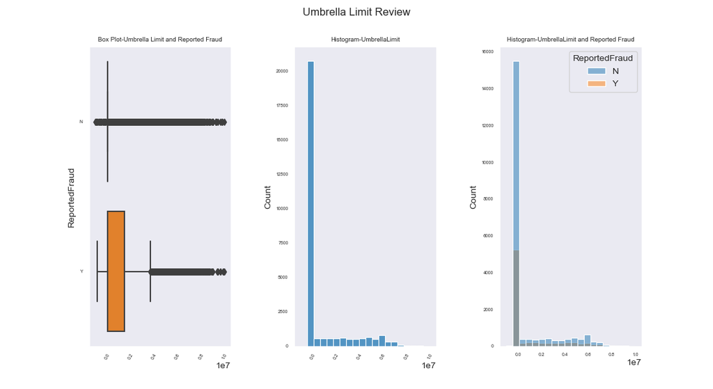

The above plots are unusual. Both box plots have a median of zero. Reported Fraud=Y has a mean of 1,000,000 while Reported Fraud=“N” mean is 918,000. Both histograms have their peak at zero and a log tail to the right.

There are only 7506 data points greater than zero. 2417 for Yes and 5089 for No. Data points greater than zero represent only 26 percent of the entire data set. Normally this would seem unusual, and we would review the raw data for errors. Checking the description of umbrella limit we find that such extreme data points are not uncommon. Umbrella insurance provides “excess liability insurance” beyond the liability insurance already in auto insurance coverage. It’s for expensive situations where medical bills and/or repairs exceed those in “base” auto policies. Auto policy holders who fall in the higher income brackets are usually the purchasers of umbrella limit. Thus, for all data points, the mean of 972,000 and max of 10,000,000 are common values. Additionally, the mean of zero is not unsurprising as not many insured choose umbrella limits for their policies.

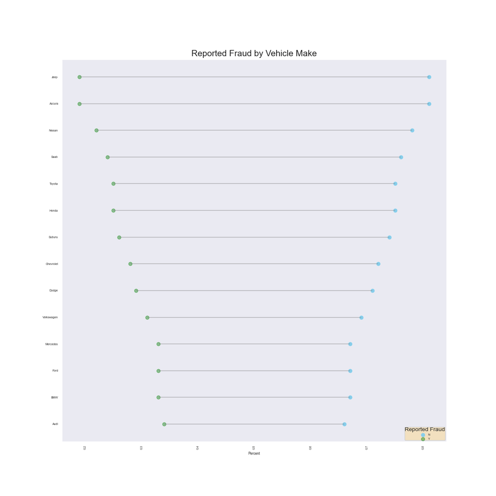

We find that Volkswagen, Mercedes, Ford, BMW, and Audi are the vehicle makes with reported fraud over 30%.

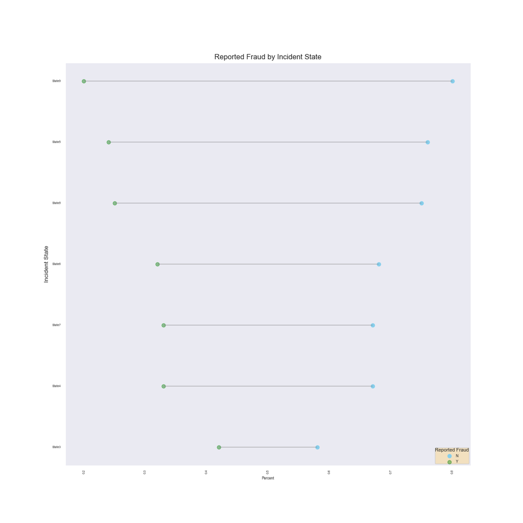

Incident States 4,6, and 7 have reported fraud just over 30% which appears significant. However, Incident state 3 stands out from the other states with a reported fraud around 42%

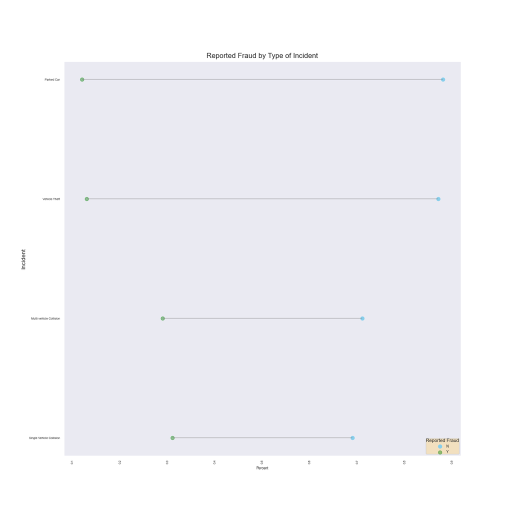

From the above plots we observe two categories stand out with respect to reported fraud. ‘Single Vehicle Collision’ and ‘Multi-vehicle collision’ from the feature ‘Type of Incident’ have claims reported as fraud at 31% and 29% respectively. The other two categories are under 14%.

## Outliers

We’ll now review our data for outliers. Our goal is not necessarily to remove observations that are indicated as outliers, it is to derive insights that may help us understand reported fraud in combination with our machine learning models.

### Numeric Review

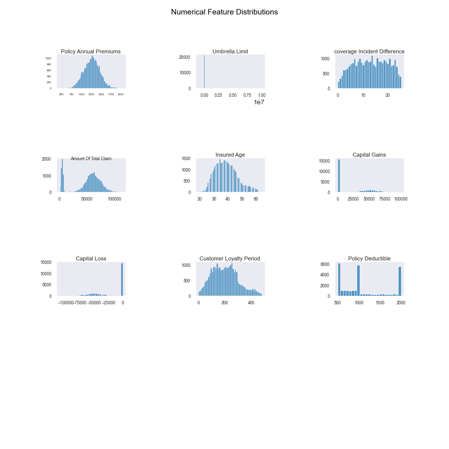

The above plots indicate that certain numerical features exhibit distributions that are not normal this we will zoom in on these features.

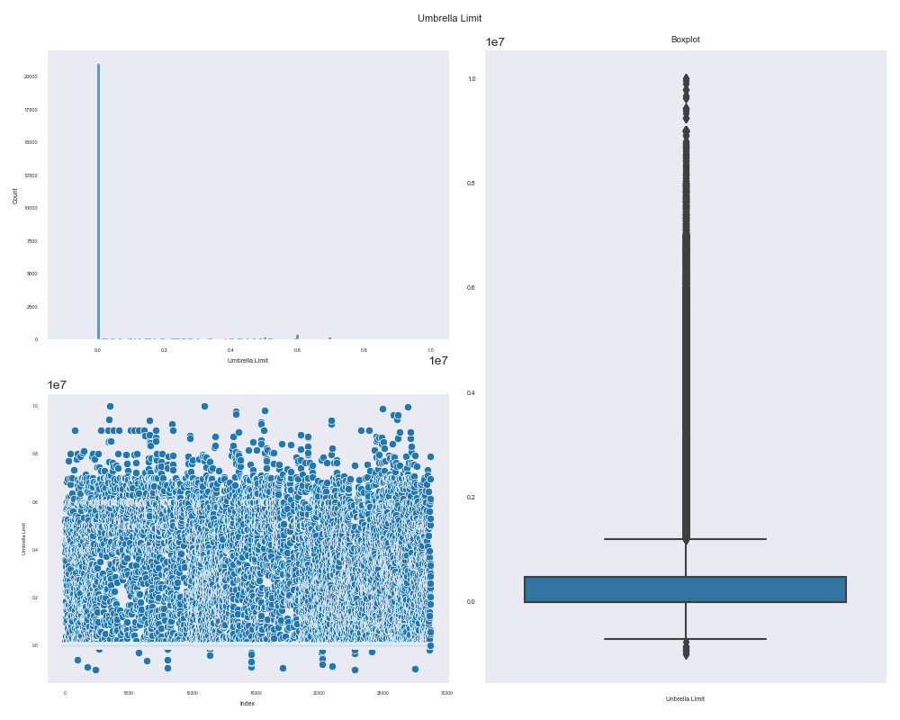

### Categorical Review

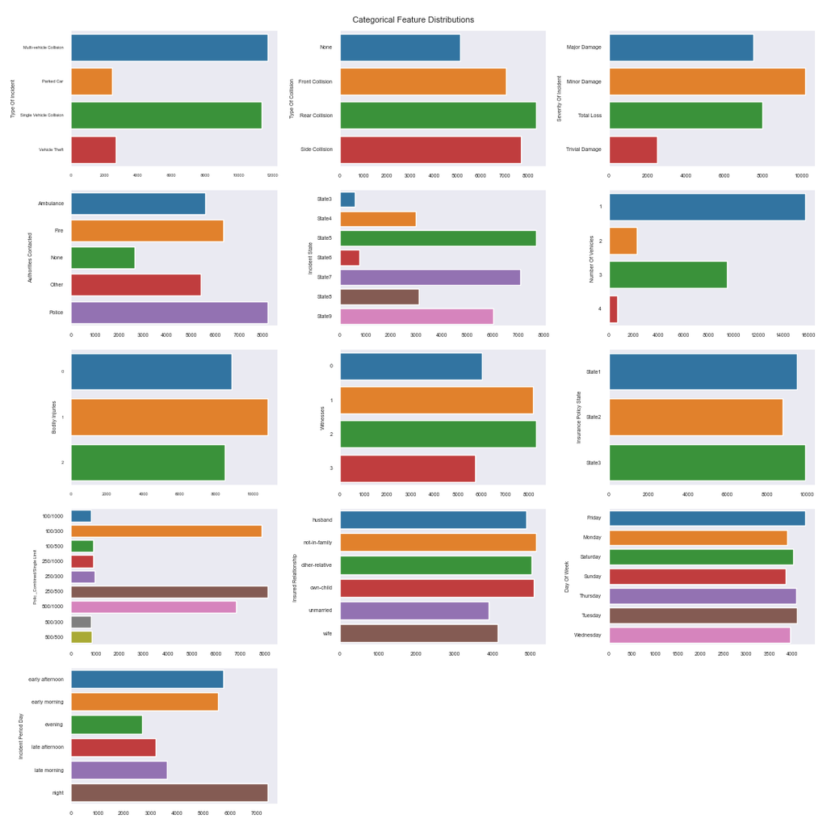

### Outlier Detection Model

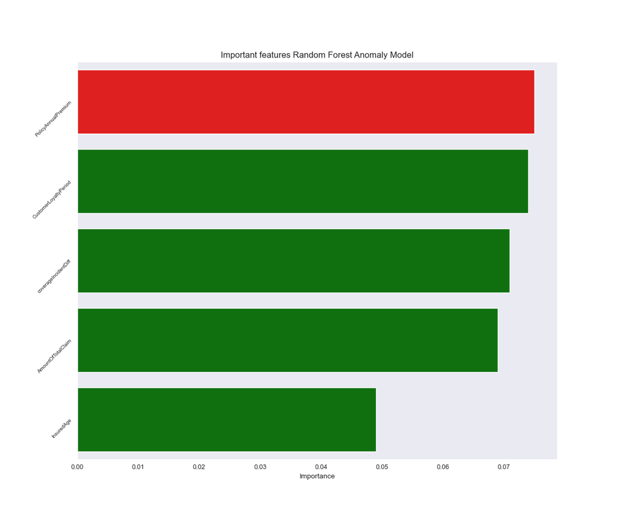

Feature Importance is a score assigned to features that defines how “important” a feature is to the model’s prediction. This means the extent to which the feature contributes to the final output. However, feature importance does not inform us if the contribution is a positive or negative impact on the final output.

In our inspection of these top features in the visualization section, the distribution between fraud and no fraud did not show differences in distribution. In order to thoroughly perform anomaly detection, we woujld include other model algorithms. Since the focus of this project is predicting fraud, anomaly detection will be a seperate project.

# Models

## Logistic Regression

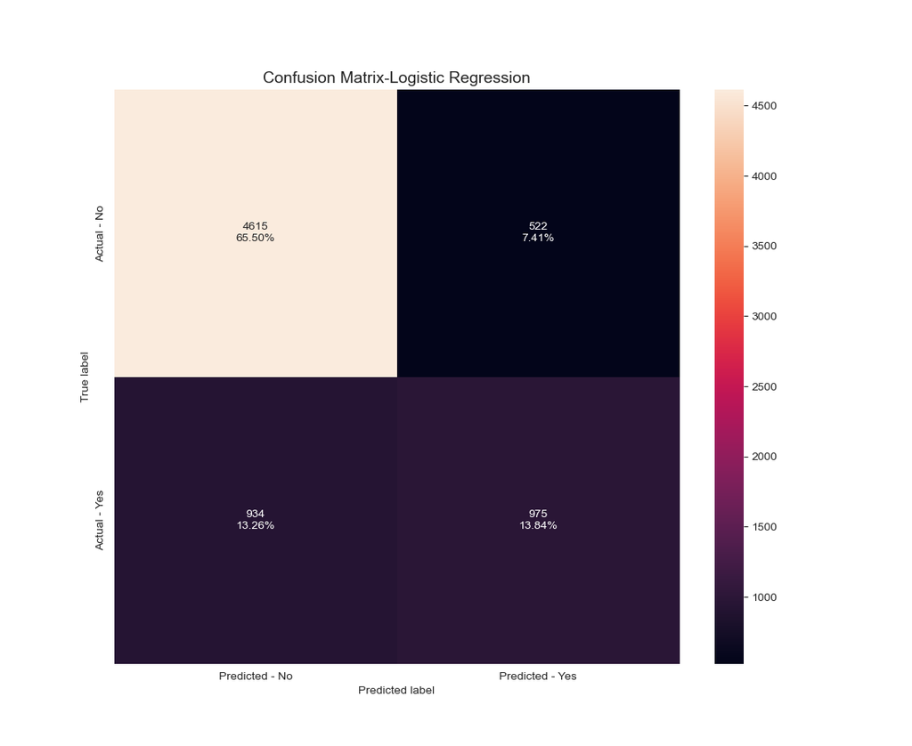

We see from the confusion matrix that 13.84% of fraud predictions were accurately predicted as Yes compared to 7.41% that were inaccurately predicted as yes.

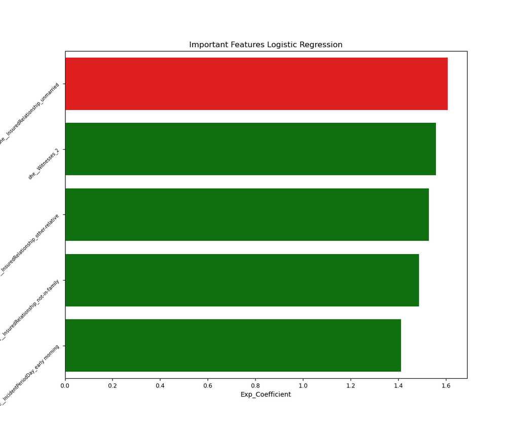

We will now look at Feature Importance. Feature Importance is a score assigned to the features of a Machine Learning model that defines how “important” is a feature to the model’s prediction. This means the extent to which the feature contributes to the final output. However, feature importance does not inform us if the contribution is a positive or negative impact on the final output.

## Support Vector Machine

Support Vector Machine (the “road machine”) is responsible for finding the decision boundary to separate different classes and maximize the margin. A decision boundary differentiates two classes. A data point falling on either side of the decision boundary can be attributed to different classes. Binary classes would be either yes or no.

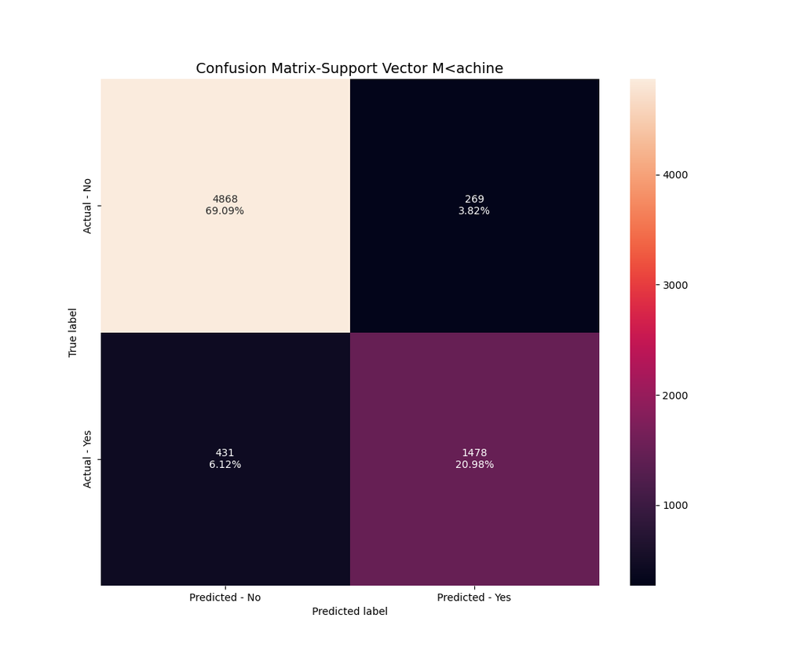

## Random Forest

Bagging involves fitting many decision trees on different samples of the same dataset and averaging the predictions.

Random Forest models are made up of individual decision trees whose predictions are combined for a final result. The final result is decided using majority rules which means that the final prediction is what the majority of the decision tree models chose. An example would be 5 models in which 3 of the 5 models predict ‘yes’ for the classification problem.

Random Forests can be made up of thousands of decision trees.

Simply put, the random forest builds multiple decision trees and merges them together to get a more accurate prediction.

[Random Forest for Beginners](https://www.analyticsvidhya.com/blog/2021/10/an-introduction-to-random-forest-algorithm-for-beginners/)

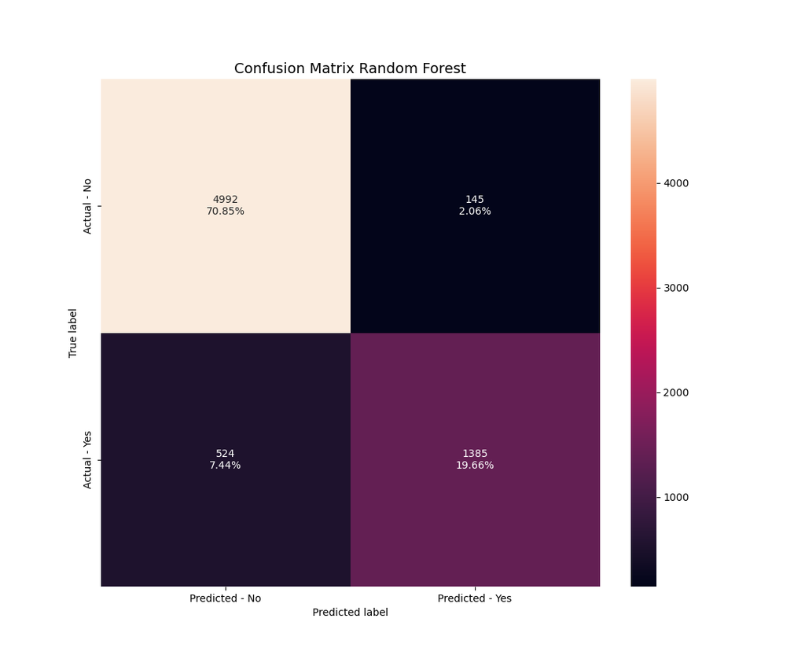

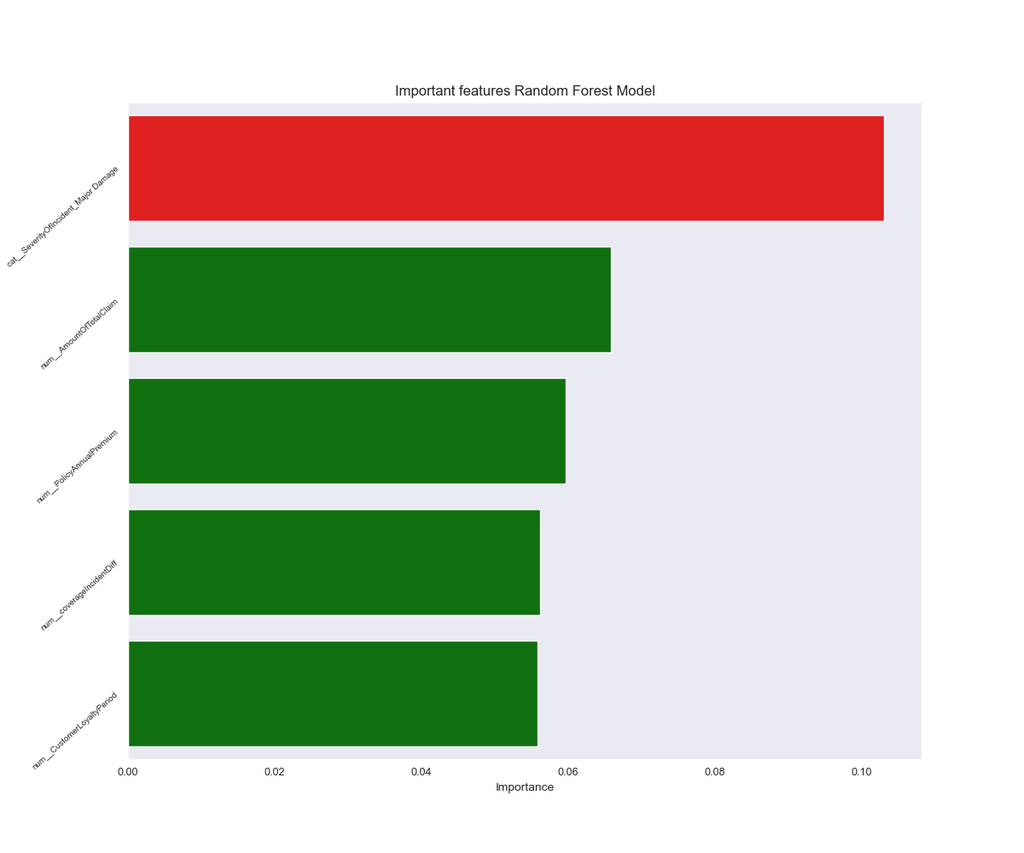

Of the top features for our random forest model, it’s interesting to note that two through five are also important features of our anomaly detection model.

## Gradient Boost

The main idea behind this algorithm is to build models sequentially and these subsequent models try to reduce the errors of the previous model. Errors are reduced by building a new model on the errors or residuals of the previous model.

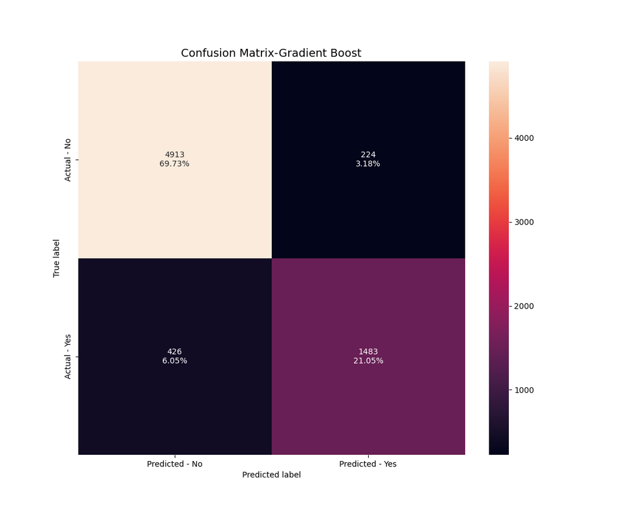

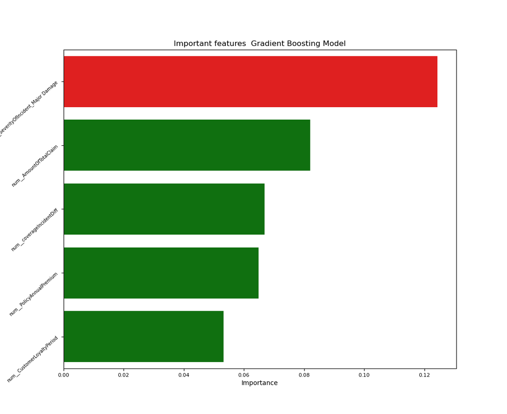

The top features of our gradient boost model are the same as those from the random forest model

## Extreme Gradient Boost

Extreme Gradient boosting is similar to gradient boosting with a few improvements. First, enhancements make it faster than other ensemble methods. Secondly, built-in regularization allows it to have an advantage in accuracy. Regularization is the process of adding information to reduce variance and prevent over fitting.

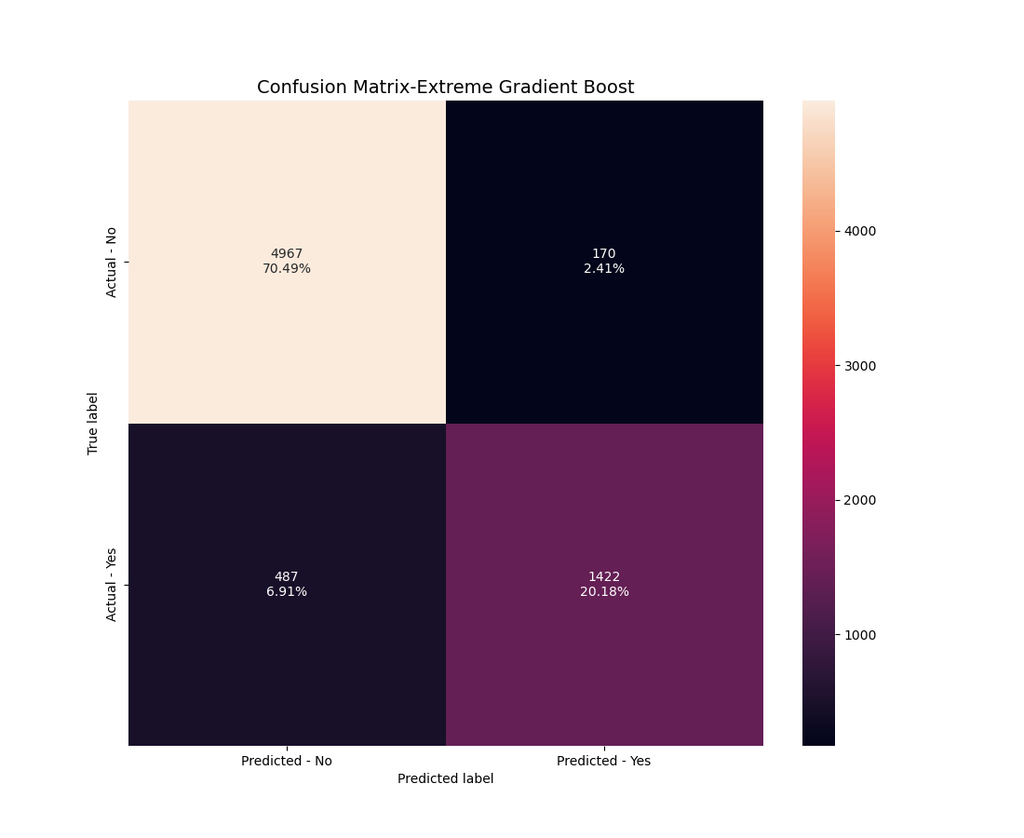

The extreme gradient classifier’s accurate and inaccurate predictions of fraud Yes are close to both random forest and svc classifiers at 20.18% and 2.41%. respectively.

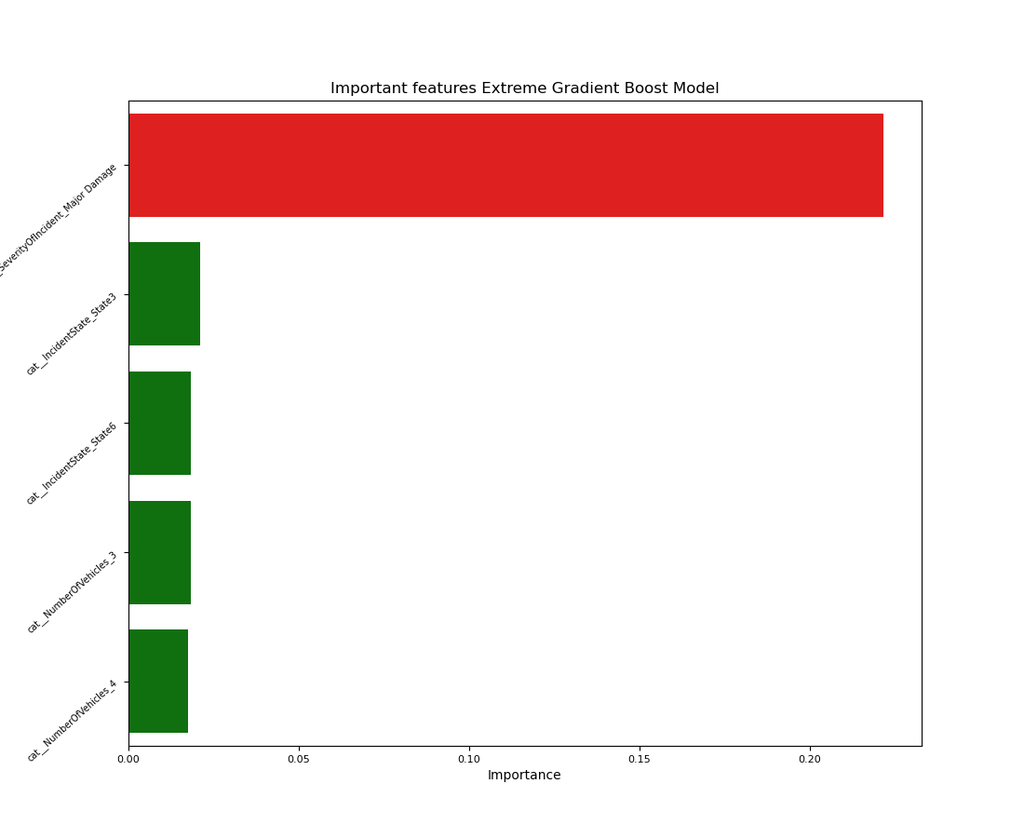

Extreme Gradient Boost’s highest scoring important feature of severity of incident level Major Damage the same as gradient boost. The difference is it’s score of 20% dominates compared to the other important features scores which hover around 2%.

# Model Comparison

## Metric Definitions

Accuracy-measures the number of predictions that are correct as a percentage of the total number of predictions that are made. As an example, if 90% of your predictions are correct, your accuracy is simply 90%. Calculation: number of correct predictions/Number of total predictions. TP+TN/(TP+TN+FP+FN)

Precision-tells us about the quality of positive predictions. It may not find all the positives but the ones that the model does classify as positive are very likely to be correct. As an example, out of everyone predicted to have defaulted, how many of them did default? So, within everything that has been predicted as a positive, precision counts the percentage that is correct. Calculation: True positives/All Positives. TP/(TP+FP)

Recall- tells us about how well the model identifies true positives. The model may find a lot of positives, yet it also will wrongly detect many positives that are not actually positives. Out of all the patients who have the disease, how many were correctly identified? So, within everything that is positive, how many did the model successfully to find. A model with low recall is not able to find all (or a large part) of the positive cases in the data. Calculated as: True Positives/(False Negatives + True Positives)

F1 Score-The F1 score is defined as the harmonic mean of precision and recall.

The formula for the F1 score is the following: 2 times((precision*Recall)/(Precision + Recall))

Since the F1 score is an average of Precision and Recall, it means that the F1 score gives equal weight to Precision and Recall.

## Train Scores

**Model Cross Validation Comparison**

Evaluation and Performance Metrics

| Model | Metrics RecallBase | Metrics RecallTune | Metrics PrecisionBase | Metrics PrecisionTune | Metrics F1Base | Metrics F1Tune | Metrics AUCBase | Metrics AUCTune | Time GridTuneTime | Time CVTime | Time CVBaseTime | Time CVTimeDiff |
| --- | --- | --- | --- | --- | --- | --- | --- | --- | --- | --- | --- | --- |
| Logistic Regresion | 0.51 | 0.51 | 0.65 | 0.65 | 0.57 | 0.57 | 0.70 | 0.70 | 1.46 | 0.66 | 1.78 | 1.12 |
| Support Vector Machine | 0.73 | 0.78 | 0.89 | 0.85 | 0.80 | 0.81 | 0.85 | 0.86 | 171.50 | 92.37 | 33.86 | -58.51 |
| Random Forest | 0.72 | 0.73 | 0.90 | 0.90 | 0.80 | 0.80 | 0.84 | 0.85 | 230.96 | 21.77 | 2.66 | -19.11 |
| Gradient Boosting | 0.55 | 0.77 | 0.74 | 0.87 | 0.63 | 0.82 | 0.74 | 0.87 | 135.59 | 42.59 | 41.63 | -0.96 |
| Extreme Gradient Boosting | 0.75 | 0.76 | 0.89 | 0.91 | 0.81 | 0.83 | 0.86 | 0.86 | 98.62 | 47.93 | 10.76 | -37.17 |

**Precsion, Recall, and F1 scores are displayed for prediction of 1 (Fraud=Yes)**

The table above presents evaluation metrics for class prediction of 1 (Yes), where the event of interest is a fraudulent submission. While all metrics are considered, Precision is our primary focus. A higher precision score indicates fewer false positives—cases where the model incorrectly flags a legitimate submission as fraudulent. Minimizing these errors is critical, as we do not want to falsely accuse a policyholder of fraud.

Recall, which reflects the rate of false negatives (predicting “No” when the actual class is “Yes”), is also important and will be the secondary metric of focus after precision.

Our next step is to compare these cross-validation results with those from the test set (unseen data). We will proceed with the three models that showed the best precision and training efficiency: SVM, Random Forest, and Extreme Gradient Boost.

**Model Test/Cross Validationm Comparison**

Evaluation Metrics

| Model | Metrics RecallBase | Metrics RecallTest | Metrics PrecisionBase | Metrics PrecisionTest | Metrics F1Base | Metrics F1Test | Metrics AUCBase | Metrics AUCTest | Difference in Cross Validation and Test Scores Recall_diff | Difference in Cross Validation and Test Scores Precision_diff | Difference in Cross Validation and Test Scores F1_diff | Difference in Cross Validation and Test Scores AUC_diff |
| --- | --- | --- | --- | --- | --- | --- | --- | --- | --- | --- | --- | --- |
| Support Vector Machine | 0.73 | 0.74 | 0.89 | 0.90 | 0.80 | 0.81 | 0.85 | 0.85 | -0.01 | -0.01 | -0.01 | 0.00 |
| Random Forest | 0.72 | 0.73 | 0.90 | 0.91 | 0.80 | 0.81 | 0.84 | 0.85 | -0.01 | -0.01 | -0.01 | -0.01 |
| Extreme Gradient Boosting | 0.75 | 0.74 | 0.89 | 0.89 | 0.81 | 0.81 | 0.86 | 0.86 | 0.01 | 0.00 | 0.00 | 0.00 |

**Precsion, Recall, and F1 scores are displayed for prediction of 1 (Fraud=Yes)**

The table above compares cross-validation scores with test set performance to evaluate how well our selected models generalize to unseen data. Specifically, we are looking for signs of overfitting or underfitting:

```
-Overfitting occurs when a model performs well on training data but poorly on new data—often indicated by training scores significantly higher than test scores.

-Underfitting happens when a model doesn’t learn the training data well, which can be suggested when
test scores are higher than training scores.
```

Examining other metrics:

[output not shown]

Given the strong overall performance and balance across metrics, Extreme Gradient Boost is selected as the final model for fitting to new data. However, Random Forest remains a strong alternative with it’s fast training time and may still be considered in further evaluations.

# New Data

```
## Predicted Fraud Percentages from New Data:
## 0    0.85
## 1    0.15
## Name: Predicted_Label, dtype: float64
```

```
## Reported Fraud Percentages from Original Data:
## N    0.73
## Y    0.27
## Name: ReportedFraud, dtype: float64
```

The results show that our model predicted 15% of our observations as fraud compared to 27% of the original data reported as fraud. This is a 12% difference. Let’s check the prediction results on our original test data.

```
## Reported Fraud Percentages from Original Data:
## 0    0.77
## 1    0.23
## Name: Predicted_Label, dtype: float64
```

The predicted labels of the test data are closer to the the original data than the those from the new data.

Let’s take a look at the predicted probabilities for both the new and test data.

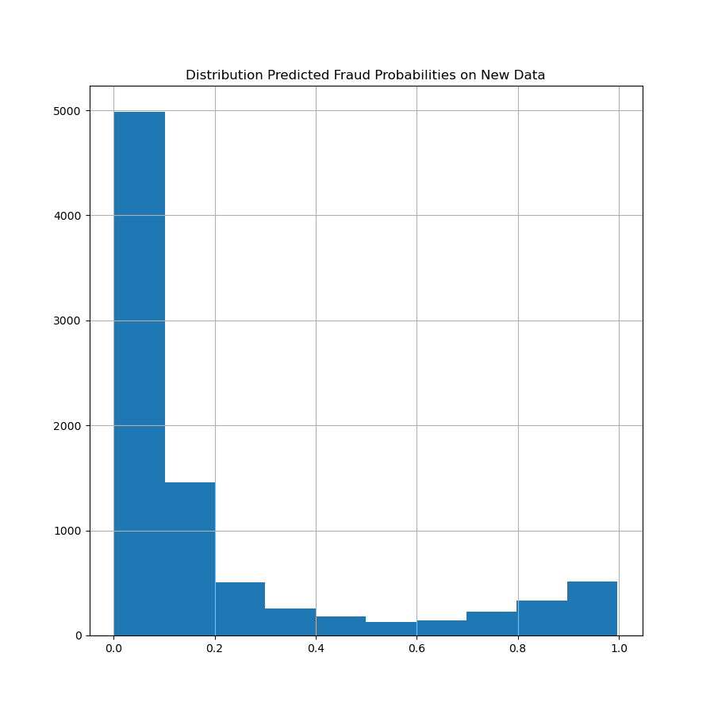

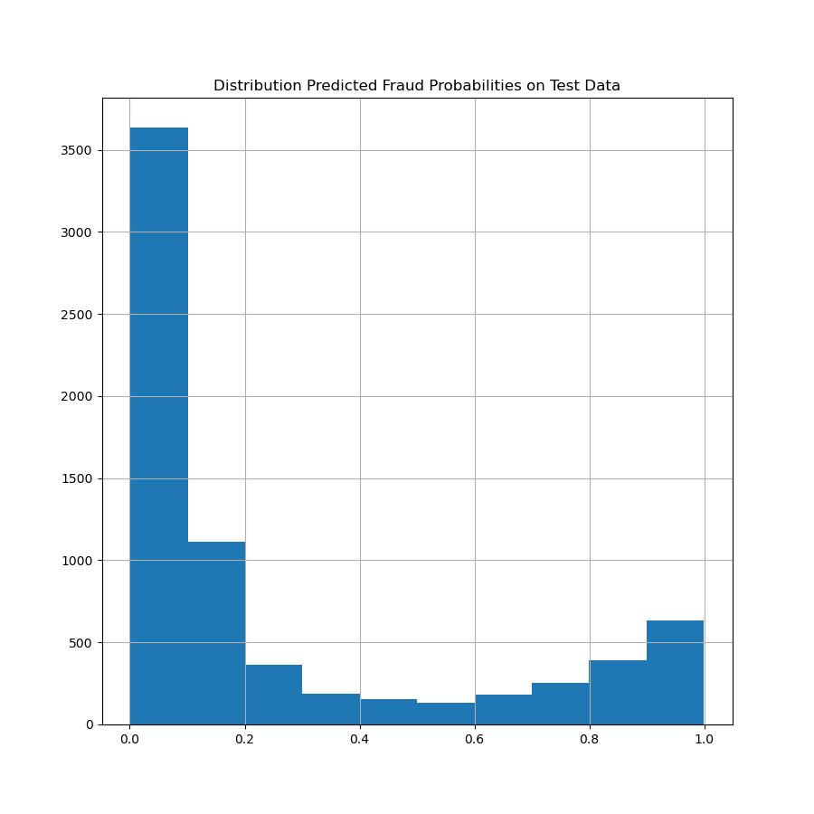

The distributions appear similar. We are interested in predicted probabilities of 50% or greater. The xg boost classifier appears to be marginally stronger at predicting reported fraud of yes on the original test data at probabilities of 70% or higher. We’ll filter our data to observe just predicted probabilities of fraud over 70%.

```
## Among cases correctly predicted as fraud (Yes), 12.30% of the predictions in the new data had
##  a predicted probability greater than 70%, compared to 18.14% in the test data.
```

It appears the xg boost classifier predicted a higher percentage of fraud on the original test set than on our new data. Assessment on the xg boost classifier would benefit from collecting additional data before a definitive judgement can be made.